# Introduction to Python and Jupyter notebooks

[Python](https://www.python.org/) is a general computing language that is very popular in the sciences and also in statistics. Code along with maths are often elegantly presented using [Jupyter](https://jupyter.org/) notebooks, where one can use Markdown and Latex. It is also possible to run R within Jupyter notebooks.

Jupyter notebooks can be run online, and also locally. An easy way to obtain Python and Juptyer is to use the [Anaconda](https://www.anaconda.com/products/individual) package.

# Maths and Stats in Python

Since Python is general computing language, you may need to install some packages to do various basic operations that are available to you by default, in say R. In what follows we illustrate some common useful operations.

```python
import numpy as np       #you may need to install this package

y = np.array([1,2,3])     # to make vectors
x = np.array([4,5,6])
print(x+y)
z=np.concatenate((x,y))   # like the combine function in R
print(z)
print(len(z))             # length of a vector
print(y[0])                # indexing starts at zero
print(y[2])
print(x[-1])               # last element of the vector

t=np.linspace(0,1,num=10)
print(t)
```

```
[5 7 9]
[4 5 6 1 2 3]
6
1
3
6
[0.         0.11111111 0.22222222 0.33333333 0.44444444 0.55555556
 0.66666667 0.77777778 0.88888889 1.        ]
```

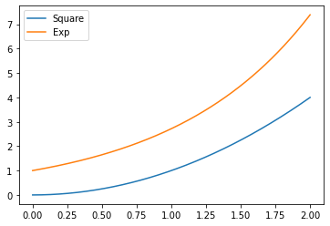

```python
import matplotlib.pyplot as plt  # In order to plot functions
t=np.linspace(0,2,num=2000)
y = pow(t, 2)
plt.plot(t,y, label='Square')
plt.plot(t,np.exp(t), label='Exp')
plt.legend(loc='upper left')
plt.show()
```

## Simulating random variables in Python

In what follows, we simulate pseudo random numbers in Python.

```python
u=np.random.random()  # calls a uniform [0,1]
v=np.random.normal(0, 1)  # calls a standard normal

print(u)
print(v)

u = [np.random.random() for _ in range(10)]  # calls 10 uniforms
print(u)
v = [ np.random.normal(0, 1) for _ in range(10)] # calls 10 standard normals
print(v)



v = np.random.standard_t(4)   # calls t-distribution with 4 degrees of freedom
print(v)



x = np.random.binomial(1, 0.3, 2) # calls two biased coin flips
print(x)
```

```
0.41033393549779884
-2.9300679955794298
[0.8296050910084788, 0.05950906080344376, 0.7816312230761072, 0.4509645370336439, 0.06289219278408187, 0.842491575355918, 0.8894556709742688, 0.7178277876520349, 0.7342539111305152, 0.9373807722630666]
[-1.5955293822714862, -0.2537310901499091, 1.5850806537649724, 0.8791258096442519, -0.08948646213292853, 0.033991504954406886, -0.4943422102704151, -1.217993723272968, -0.2066985861489827, -0.23965813348161952]
-0.9306777424675726
[1 0]
```

## Von Neumann's method of creating a fair toss, from a possibly biased coin of unknown parameter

Suppose we are given a coin, with unknown parameter $p$, so that the probability that the outcome of a flip is *heads* is $p$ which is not necessary $\tfrac{1}{2}$. We want to generate a method of simulating a fair toss. It is easy to verify that the following method works. We toss the coin twice:

- If we see HT, then we consider this as H;
- If we see TH, then we consider this T;
- If we see HH or TT, we lose, and we start all over, and have to toss the coin at least twice again.

The following code will illustrate the use a *function* and a *while* loop.

```python
def vn(p):
    x=np.array([1,1])
    num=np.sum(x)
    while num==0 or num==2:
        x = np.random.binomial(1, p, 2)
        num = np.sum(x)
    return x[0]

z= vn(0.3)
print(z)
```

```
0
```

We run some simple (but not complete) verfications to make sure the defined function does indeed give fair flip, when $p=0.2$.

```python
x = [vn(0.2)  for _ in range(10)]
print(x)
x = [vn(0.2)  for _ in range(1000)]
print(np.mean(x))
print(np.std(x))
```

```
[0, 1, 0, 1, 1, 1, 0, 0, 0, 0]
0.499
0.49999899999899994
```

# Other resources

- [My introduction from 2020](https://tsoo-math.github.io/ucl/first.html)
- [Patrick Walls](https://www.math.ubc.ca/~pwalls/math-python/) site at UBC.
- [ipynb Source for this file](https://tsoo-math.github.io/ucl2/intro-to-python.ipynb)

```python
from datetime import datetime
print(datetime.now())
```

```
2021-09-23 20:38:51.881533
```